# ESTADO DEL ARTE DE LOS MODELOS DE RECOMENDACIÓN: EJEMPLO DE APLICACIÓN A LOS DATOS DE NETFLIX

- Curso: Machine Learning
- Integrantes:
  - Marina Ortín
  - Mayra Goicochea

## Introducción

### Objetivo

Netflix dispone de un sistema de recomendación de películas llamado CinematchSM, que ofrece recomendaciones personalizadas al usuario, en base a sus preferencias e historial en la plataforma. En 2006 se lanza un concurso en el que el objetivo es mejorar el sistema actual de recomendación, basándose en los feedback recibidos de los usuarios, a través de las calificaciones de las películas vistas.

### Restricciones

Para participar en este concurso y poder hacer medidas homogéneas del desempeño, Netflix facilitó una base de datos, compuesta por cinco archivos, para que los participantes prueben sus códigos. Cinematch ofrece un RMSE de 0.9514 en la data de entrenamiento, y 0.9525 en la de validación. El equipo ganador debe mejorar en un 10% la medida en la muestra de validación, alcanzando un 0.8572.

### Archivos utilizados

1. combined_data_1.txt
2. combined_data_2.txt
3. combined_data_3.txt
4. combined_data_4.txt
5. movie_titles.csv

### Planteamiento

Dada una película y usuario, se pretende predecir la puntuación que recibiría.

### Métricas de desempeño

1. Mean Absolute Percentage Error
2. Root Mean Square Error

```python
from datetime import datetime
import pandas as pd
import numpy as np
import seaborn as sns
import os
import random
import matplotlib
import matplotlib.pyplot as plt
from scipy import sparse
from sklearn.metrics.pairwise import cosine_similarity
from sklearn.metrics import mean_squared_error

plt.style.use("seaborn-pastel")
```

```python
import xgboost as xgb
from surprise import Reader, Dataset
from surprise import BaselineOnly
from surprise import KNNBaseline
from surprise import SVD
from surprise import SVDpp
from surprise.model_selection import GridSearchCV
```

## Datos

### Data Pre-processing

En primer lugar, dado que disponemos de distintas fuentes de información, como paso previo al análisis exploratorio, los combinaremos en un único documento, que llamaremos 'data.csv'. Este archivo será la base de nuestro análisis. La operación de guardado realizada nos permitirá invocarlo y reducir el tiempo de procesamiento.

```python
data_path = "../data"
movie_file = "movie_titles.csv"
data_files=['combined_data_1.txt','combined_data_2.txt',
           'combined_data_3.txt', 'combined_data_4.txt']
```

```python
os.chdir(data_path)
```

```python
start = datetime.now()

if not os.path.isfile('data.csv'):
    # Crea un archivo concatenado de todos los archivos de rating
    data = open('data.csv', mode='w')
    row = list()
    for file in data_files:
        print("Leyendo ratings del archivo {}...".format(file))
        with open(file) as f:
            for line in f:
                del row[:] # you don't have to do this.
                line = line.strip()
                if line.endswith(':'):
                    # All below are ratings for this movie, until another movie appears.
                    movie_id = line.replace(':', '')
                else:
                    row = [x for x in line.split(',')]
                    row.insert(0, movie_id)
                    data.write(','.join(row))
                    data.write('\n')
        print("Finalizado.\n")
    data.close()
print('Tiempo de procesamiento :', datetime.now() - start)
```

```
Tiempo de procesamiento : 0:00:00
```

Creamos el dataframe a partir del archivo data.csv:

```python
# Crea el dataframe de los datos del archivo
if not os.path.isfile("NetflixData.pkl"):
    startTime = datetime.now()
    Final_Data = pd.read_csv("data.csv", sep=",", names = ["MovieID","CustID", "Ratings", "Date"])
    Final_Data["Date"] = pd.to_datetime(Final_Data["Date"])
    Final_Data.sort_values(by = "Date", inplace = True)
    print("Tiempo de procesamiento :"+str(datetime.now() - startTime))
```

Creamos un archivo tipo 'pickle' para optimizar los tiempos de cómputo:

```python
# storing pandas dataframe as a picklefile for later use
if not os.path.isfile("NetflixData.pkl"):
    Final_Data.to_pickle("NetflixData.pkl")
else:
    Final_Data = pd.read_pickle("NetflixData.pkl")
```

## Análisis Exploratorio (EDA)

Iniciamos el análisis exploratorio con el análisis del dataset único que hemos creado previamente; como podemos ver, se compone de 4 columnas:

- código de película: en este ejercicio, se toman en consideración 17.770 títulos.
- código de usuario: existen 480.189 usuarios distintos en este dataset.
- puntuación: oscila en un rango entre 1 y 5, siendo el valor más frecuente 4 y la media, 3.6
- fecha: los registros abarcan desde 11/11/1999 hasta 31/12/2005

Por otra parte, disponemos de 100.480.507 de observaciones.

```python
Final_Data.head(2)
```

|  | MovieID | CustID | Ratings | Date |
| --- | --- | --- | --- | --- |
| 56431994 | 10341 | 510180 | 4 | 1999-11-11 |
| 9056171 | 1798 | 510180 | 5 | 1999-11-11 |

```python
print("Netflix Data:")
print("Total número de calificaciones = "+str(Final_Data.shape[0]))
print("Número de usuarios = "+str(len(np.unique(Final_Data["CustID"]))))
print("Número de peliculas = "+str(len(np.unique(Final_Data["MovieID"]))))
```

```
Netflix Data:
Total número de calificaciones = 100480507
Número de usuarios = 480189
Número de peliculas = 17770
```

**Fecha**

```python
Final_Data['Date'].min(),Final_Data['Date'].max()
```

```
(Timestamp('1999-11-11 00:00:00'), Timestamp('2005-12-31 00:00:00'))
```

```python
Final_Data.shape
```

```
(100480507, 4)
```

**Puntuación**

Nuestra variable numérica, puntuación, tiene una rango de 1 a 5, siendo estos nuestros valores mínimo y máximo, respectivamente. Por otra parte, la puntuación más frecuente es 4.

```python
Final_Data.describe()["Ratings"]
```

```
count    1.004805e+08
mean     3.604290e+00
std      1.085219e+00
min      1.000000e+00
25%      3.000000e+00
50%      4.000000e+00
75%      4.000000e+00
max      5.000000e+00
Name: Ratings, dtype: float64
```

### Valores Ausentes

Como parte del análisis exploratorio básico, se realiza una comprobación para verificar que no existen valores ausentes.

```python
print("Número de NaN = "+str(Final_Data.isnull().sum()))
```

```
Número de NaN = MovieID    0
CustID     0
Ratings    0
Date       0
dtype: int64
```

### Eliminación de Duplicados

Comprobamos, asimismo, que no existan registros duplicados que distorsionen nuestros resultados.

```python
duplicates = Final_Data.duplicated(["MovieID","CustID", "Ratings"])
print("Número de registros duplicados = "+str(duplicates.sum()))
```

```
Número de registros duplicados = 0
```

## Separación de muestras de entrenamiento y validación (80:20)

```python
if not os.path.isfile("TrainData.pkl"):
    Final_Data.iloc[:int(Final_Data.shape[0]*0.80)].to_pickle("TrainData.pkl")
    Train_Data = pd.read_pickle("TrainData.pkl")
    Train_Data.reset_index(drop = True, inplace = True)
else:
    Train_Data = pd.read_pickle("TrainData.pkl")
    Train_Data.reset_index(drop = True, inplace = True)

if not os.path.isfile("TestData.pkl"):
    Final_Data.iloc[int(Final_Data.shape[0]*0.80):].to_pickle("TestData.pkl")
    Test_Data = pd.read_pickle("TestData.pkl")
    Test_Data.reset_index(drop = True, inplace = True)
else:
    Test_Data = pd.read_pickle("TestData.pkl")
    Test_Data.reset_index(drop = True, inplace = True)
```

### Data Entrenamiento: Estadísticas

```python
print("Datos de Entrenamiento:")
print("Total número de calificaciones = "+str(Train_Data.shape[0]))
print("Número de usuarios = "+str(len(np.unique(Train_Data["CustID"]))))
print("Número de peliculas = "+str(len(np.unique(Train_Data["MovieID"]))))
print("Valor máximo de User ID = "+str(max(Train_Data["CustID"].values)))
print("Valor máximo de Movie ID = "+str(max(Train_Data["MovieID"].values)))
```

```
Datos de Entrenamiento:
Total número de calificaciones = 80384405
Número de usuarios = 405041
Número de peliculas = 17424
Valor máximo de User ID = 2649429
Valor máximo de Movie ID = 17770
```

### Data Validación: Estadísticas

```python
print("Datos de Pruebas:")
print("Total número de calificaciones = "+str(Test_Data.shape[0]))
print("Número de usuarios = "+str(len(np.unique(Test_Data["CustID"]))))
print("Número de peliculas = "+str(len(np.unique(Test_Data["MovieID"]))))
print("Valor máximo de User ID = "+str(max(Test_Data["CustID"].values)))
print("Valor máximo de Movie ID = "+str(max(Test_Data["MovieID"].values)))
```

```
Datos de Pruebas:
Total número de calificaciones = 20096102
Número de usuarios = 349312
Número de peliculas = 17757
Valor máximo de User ID = 2649429
Valor máximo de Movie ID = 17770
```

### Análisis de distribución de calificaciones

```python
def changingLabels(number):
    return str(number/10**6) + "M"
```

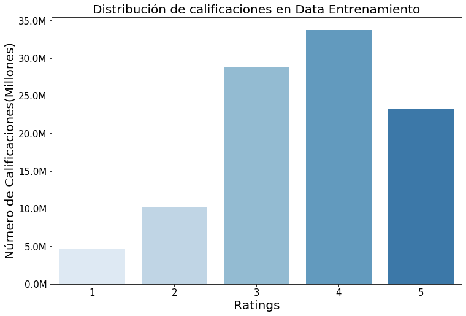

```python
plt.figure(figsize = (12, 8))
ax = sns.countplot(x="Ratings", data=Final_Data,palette=sns.color_palette('Blues'))

ax.set_yticklabels([changingLabels(num) for num in ax.get_yticks()])
plt.tick_params(labelsize = 15)
plt.title("Distribución de calificaciones en Data Entrenamiento", fontsize = 20)
plt.xlabel("Ratings", fontsize = 20)
plt.ylabel("Número de Calificaciones(Millones)", fontsize = 20)
plt.show()
```

```python
Final_Data["DayOfWeek"] = Final_Data.Date.dt.weekday_name
```

### Número de Puntuaciones por Mes

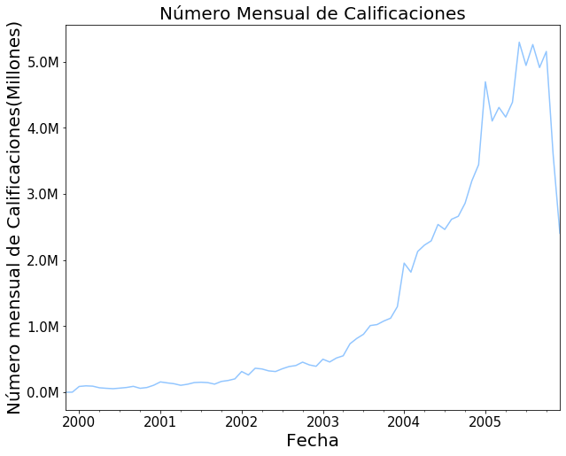

```python
plt.figure(figsize = (10,8))
ax = Final_Data.resample("M", on = "Date")["Ratings"].count().plot()
ax.set_yticklabels([changingLabels(num) for num in ax.get_yticks()])
ax.set_title("Número Mensual de Calificaciones", fontsize = 20)
ax.set_xlabel("Fecha", fontsize = 20)
ax.set_ylabel("Número mensual de Calificaciones(Millones)", fontsize = 20)
plt.tick_params(labelsize = 15)
plt.show()
```

### Comportamiento de los usuarios

¿Cuál es el comportamiento típico de un usuario de Netflix? Como se puede observar, la mayoría de usuarios emiten pocas calificaciones (en torno a 200 calificaciones). Sin embargo, algunos usuarios son muy activos en esta plataforma, llegando a puntuar miles de títulos. Por ejemplo, el usuario con mayor número de interacciones es el 305344, con 17.653 calificaciones.

```python
no_of_rated_movies_per_user = Final_Data.groupby(by = "CustID")["Ratings"].count().sort_values(ascending = False)
```

```python
no_of_rated_movies_per_user.head()
```

```
CustID
305344     17653
387418     17436
2439493    16565
1664010    15813
2118461    14831
Name: Ratings, dtype: int64
```

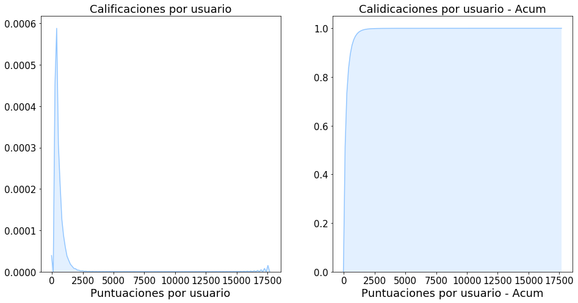

```python
fig, axes = plt.subplots(nrows = 1, ncols = 2, figsize=(14,7))

sns.kdeplot(no_of_rated_movies_per_user.values, shade = True, ax = axes[0])
axes[0].set_title("Calificaciones por usuario", fontsize = 18)
axes[0].set_xlabel("Puntuaciones por usuario", fontsize = 18)
axes[0].tick_params(labelsize = 15)

sns.kdeplot(no_of_rated_movies_per_user.values, shade = True, cumulative = True, ax = axes[1])
axes[1].set_title("Calidicaciones por usuario - Acum", fontsize = 18)
axes[1].set_xlabel("Puntuaciones por usuario - Acum", fontsize = 18)
axes[1].tick_params(labelsize = 15)

fig.subplots_adjust(wspace=2)
plt.tight_layout()
plt.show()
```

```python
print("Calificaciones de películas por usuario:")
no_of_rated_movies_per_user.describe()
```

```
Calificaciones de películas por usuario:
```

```
count    480189.000000
mean        209.251997
std         302.339155
min           1.000000
25%          39.000000
50%          96.000000
75%         259.000000
max       17653.000000
Name: Ratings, dtype: float64
```

### Popularidad de los títulos

¿Tienen todas las películas el mismo impacto? Como podemos observar en el gráfico adjunto, el comportamiento es asimétrico; existen películas con una gran repercusión (interpretada como el número de votos recibidos), mientras que otras películas no alcanzan este nivel de impacto.

```python
no_of_ratings_per_movie = Final_Data.groupby(by = "MovieID")["Ratings"].count().sort_values(ascending = False)
```

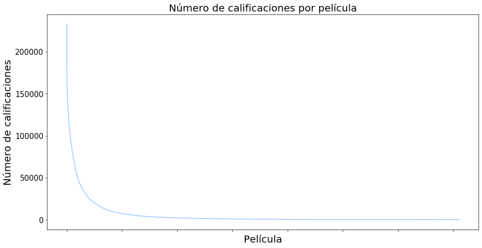

```python
fig = plt.figure(figsize = (12, 6))
axes = fig.add_axes([0.1,0.1,1,1])
plt.title("Número de calificaciones por película", fontsize = 20)
plt.xlabel("Película", fontsize = 20)
plt.ylabel("Número de calificaciones", fontsize = 20)
plt.plot(no_of_ratings_per_movie.values)
plt.tick_params(labelsize = 15)
axes.set_xticklabels([])
plt.show()
```

### Distribución del consumo

¿Cómo se distribuyen las calificaciones de películas a lo largo de la semana? Suponiendo que la calificación se produzca justo después de ver la película, observamos que el uso de esta plataforma se concentra en días entre semana, cayendo su consumo, teóricamente, en fines de semana.

Sin embargo, el día en que se califica la película no influye en la puntuación obtenida, como se muestra en el boxplot, a continuación.

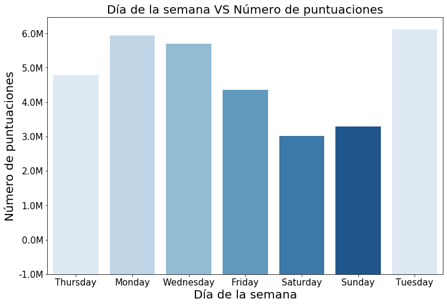

```python
fig = plt.figure(figsize = (12, 8))

axes = sns.countplot(x = "DayOfWeek", data = Final_Data, palette=sns.color_palette('Blues'))
axes.set_title("Día de la semana VS Número de puntuaciones", fontsize = 20)
axes.set_xlabel("Día de la semana", fontsize = 20)
axes.set_ylabel("Número de puntuaciones", fontsize = 20)
axes.set_yticklabels([changingLabels(num) for num in ax.get_yticks()])
axes.tick_params(labelsize = 15)

plt.show()
```

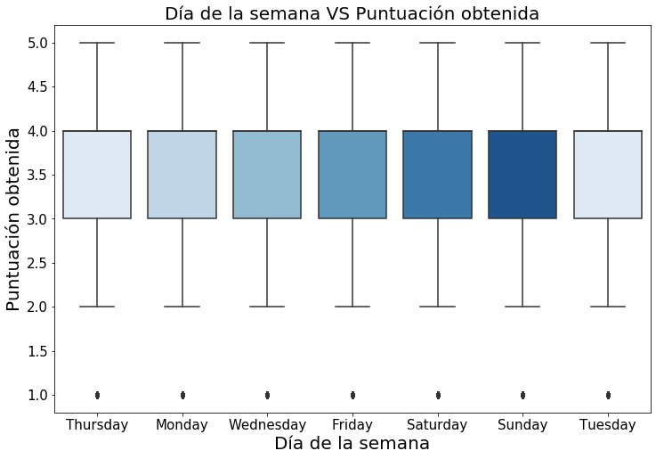

```python
fig = plt.figure(figsize = (12, 8))

axes = sns.boxplot(x = "DayOfWeek", y = "Ratings", data = Final_Data, palette=sns.color_palette('Blues'))
axes.set_title("Día de la semana VS Puntuación obtenida", fontsize = 20)
axes.set_xlabel("Día de la semana", fontsize = 20)
axes.set_ylabel("Puntuación obtenida", fontsize = 20)
axes.tick_params(labelsize = 15)

plt.show()
```

Podemos cuantificar los resultados obtenidos en el boxplot anterior, a través del cálculo de la media de puntuación por día de la semana. Como se puede observar, las diferencias no son significativas entre días.

```python
average_ratings_dayofweek = Final_Data.groupby(by = "DayOfWeek")["Ratings"].mean()
print("Puntuación media por día de la semana")
print(average_ratings_dayofweek)
```

```
Puntuación media por día de la semana
DayOfWeek
Friday       3.605892
Monday       3.597735
Saturday     3.614754
Sunday       3.616449
Thursday     3.604305
Tuesday      3.595808
Wednesday    3.604725
Name: Ratings, dtype: float64
```

## Creación de matriz dispersa Usuario-Película

Son matrices en las cuales la gran mayoría de las entradas son cero. Los sistemas de recomendación articulan su funcionamiento en torno al uso de estos elementos.

```python
startTime = datetime.now()
print("Creamos una sparse matrix USER_ITEM para la muestra de entrenamiento")
if os.path.isfile("TrainUISparseData.npz"):
    print("Sparse Matrix creada correctamente. Cargando Sparse Matrix")
    TrainUISparseData = sparse.load_npz("TrainUISparseData.npz")
    print("Dimensiones de Sparse matrix de set de entrenamiento = "+str(TrainUISparseData.shape))

else:
    print("Creando sparse data")
    TrainUISparseData = sparse.csr_matrix((Train_Data.Ratings, (Train_Data.CustID, Train_Data.MovieID)))
    print("Creación finalizada. Dimensiones de la sparse matrix = "+str(TrainUISparseData.shape))
    print("Guardando en disco.")
    sparse.save_npz("TrainUISparseData.npz", TrainUISparseData)
    print("Fin\n")

print(datetime.now() - startTime)
```

```
Creamos una sparse matrix USER_ITEM para la muestra de entrenamiento
Sparse Matrix creada correctamente. Cargando Sparse Matrix
Dimensiones de Sparse matrix de set de entrenamiento = (2649430, 17771)
0:00:04.245646
```

```python
startTime = datetime.now()
print("Creamos una sparse matrix USER_ITEM para la muestra de validación")
if os.path.isfile("TestUISparseData.npz"):
    print("Sparse Matrix creada correctamente. Cargando Sparse Matrix")
    TestUISparseData = sparse.load_npz("TestUISparseData.npz")
    print("Dimensiones de Sparse matrix de set de validación = "+str(TestUISparseData.shape))
else:
    print("Creando sparse data")
    TestUISparseData = sparse.csr_matrix((Test_Data.Ratings, (Test_Data.CustID, Test_Data.MovieID)))
    print("Creación finalizada. Dimensiones de la sparse matrix = "+str(TestUISparseData.shape))
    print("Guardando en disco.")
    sparse.save_npz("TestUISparseData.npz", TestUISparseData)
    print("Fin\n")

print(datetime.now() - startTime)
```

```
Creamos una sparse matrix USER_ITEM para la muestra de validación
Sparse Matrix creada correctamente. Cargando Sparse Matrix
Dimensiones de Sparse matrix de set de validación = (2649430, 17771)
0:00:01.084101
```

Observamos que ambas matrices de entrenamiento y test tienen las mismas dimensiones; esto se debe a que la dimensión depende de los códigos máximos de película y usuario; estos se encuentran presentes en ambas muestras:

- Como vimos anteriormente, un usuario medio realiza unas 200 puntuaciones en la plataforma, por lo que en el dataset original tendrá un registro por cada puntuación, lo que explicaría su aparición en ambos conjuntos.
- Por otra parte, hemos podido comprobar que las películas más puntuadas alcanzan varios miles de votos, reflejándose en el dataset como un registro por cada voto emitido. Estas apariciones múltiples explican el hecho de que una misma película aparezca a la vez en los conjuntos de entrenamiento y de validación.

```python
rows,cols = TrainUISparseData.shape
presentElements = TrainUISparseData.count_nonzero()

print("Dispersión de la matriz de entrenamiento : {}% ".format((1-(presentElements/(rows*cols)))*100))
```

```
Dispersión de la matriz de entrenamiento : 99.8292709259195%
```

```python
rows,cols = TestUISparseData.shape
presentElements = TestUISparseData.count_nonzero()

print("Dispersión de la matriz de validación : {}% ".format((1-(presentElements/(rows*cols)))*100))
```

```
Dispersión de la matriz de validación : 99.95731772988694%
```

### Puntuaciones medias global, por Usuario y por Película

```python
def getAverageRatings(sparseMatrix, if_user):
    ax = 1 if if_user else 0
    sumOfRatings = sparseMatrix.sum(axis = ax).A1
    noOfRatings = (sparseMatrix!=0).sum(axis = ax).A1
    rows, cols = sparseMatrix.shape
    averageRatings = {i: sumOfRatings[i]/noOfRatings[i] for i in range(rows if if_user else cols) if noOfRatings[i]!=0}
    return averageRatings
```

### Global Average Rating

```python
Global_Average_Rating = TrainUISparseData.sum()/TrainUISparseData.count_nonzero()
print("Global Average Rating {}".format(Global_Average_Rating))
```

```
Global Average Rating 3.582890686321557
```

### Puntuación media por usuario

```python
AvgRatingUser = getAverageRatings(TrainUISparseData, True)
```

```python
print("Puntuación media del usuario 25 = {}".format(AvgRatingUser[25]))
```

```
Puntuación media del usuario 25 = 3.5
```

### Puntuación media por película

```python
AvgRatingMovie = getAverageRatings(TrainUISparseData, False)
```

```python
print("Puntuación media de la película 4500 = {}".format(AvgRatingMovie[4500]))
```

```
Puntuación media de la película 4500 = 3.28
```

### Media de puntuaciones por usuario y película

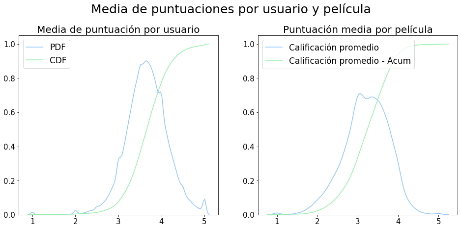

```python
fig, axes = plt.subplots(nrows = 1, ncols = 2, figsize = (16, 7))
fig.suptitle('Media de puntuaciones por usuario y película', fontsize=25)

user_average = [rats for rats in AvgRatingUser.values()]
sns.distplot(user_average, hist = False, ax = axes[0], label = "PDF")
sns.kdeplot(user_average, cumulative = True, ax = axes[0], label = "CDF")
axes[0].set_title("Media de puntuación por usuario", fontsize=20)
axes[0].tick_params(labelsize = 15)
axes[0].legend(loc='upper left', fontsize = 17)

movie_average = [ratm for ratm in AvgRatingMovie.values()]
sns.distplot(movie_average, hist = False, ax = axes[1], label = "Calificación promedio")
sns.kdeplot(movie_average, cumulative = True, ax = axes[1], label = "Calificación promedio - Acum")
axes[1].set_title("Puntuación media por película", fontsize=20)
axes[1].tick_params(labelsize = 15)
axes[1].legend(loc='upper left', fontsize = 17)

plt.subplots_adjust(wspace=0.2, top=0.85)
plt.show()
```

### Arranque en frío

El arranque en frío es un problema típico de los sistemas de recomendación. Los sistemas de recomendación forman un tipo específico de técnicas de filtrado de información que tratan de presentar información por ítems (películas, música, libros, noticias, imágenes y páginas Web) que son de probable interés para los usuarios. Típicamente, un sistema recomendador compara el perfil de usuario con algunas características de referencia.

Estas características pueden ser desde ítems de información (aproximaciones basadas en contenido) o basado en el ambiente social en el cual se desenvuelven los usuarios (la aproximación de filtrado colaborativo)

En el enfoque basado en el contenido, el sistema debe ser capaz de hacer coincidir las características de un elemento en contra de las características más importantes en el perfil del usuario. Para ello, es preciso construir un modelo lo suficientemente detallado de los gustos del usuario y sus preferencias a través de la especificación de sus preferencias. Esto puede hacerse ya sea explícitamente (realizando preguntas al usuario) o implícitamente (por la observación del comportamiento del usuario). En ambos casos, el problema de arranque en frío implicaría que el usuario tiene que dedicar una cantidad de esfuerzos utilizando el sistema en su estado ‘mudo’ lo cual contribuye a la construcción de su perfil de usuario antes de que el sistema pueda empezar a proporcionar cualquier recomendación inteligente [1]

#### Arranque en frío - Usuarios.

```python
total_users = len(np.unique(Final_Data["CustID"]))
train_users = len(AvgRatingUser)
uncommonUsers = total_users - train_users

print("Número total de usuarios = {}".format(total_users))
print("Número de usuarios presentes en muestra de entrenamiento = {}".format(train_users))
print("Número de usuarios ausentes en muestra de entrenamiento = {}({}%)".format(uncommonUsers, np.round((uncommonUsers/total_users)*100), 2))
```

```
Número total de usuarios = 480189
Número de usuarios presentes en muestra de entrenamiento = 405041
Número de usuarios ausentes en muestra de entrenamiento = 75148(16.0%)
```

#### Arranque en frío - Películas

```python
total_movies = len(np.unique(Final_Data["MovieID"]))
train_movies = len(AvgRatingMovie)
uncommonMovies = total_movies - train_movies

print("Número total de películas = {}".format(total_movies))
print("Número de películas presentes en muestra de entrenamiento = {}".format(train_movies))
print("Número de películas ausentes en muestra de entrenamiento = {}({}%)".format(uncommonMovies, np.round((uncommonMovies/total_movies)*100), 2))
```

```
Número total de películas = 17770
Número de películas presentes en muestra de entrenamiento = 17424
Número de películas ausentes en muestra de entrenamiento = 346(2.0%)
```

## Matrices de similaridad

### Matrices de similaridad entre usuarios

Se tiene 480.189 usuarios en la muestra completa y sabemos que entre ellos pueden haber características semejantes, que nos permite recomendar títulos de películas dado sus pares similares. ¿Cómo identificar los usuarios similares? Para ello usaremos la matriz de similitud, que es una matriz de puntajes que expresa su semejanza.

El cálculo de la matriz completa de similaridad entre usuarios, en nuestro caso, no es posible, dada la limitada capacidad de cómputo y tiempo disponible. Por ello, a efectos de demostración, realizaremos el ejercicio con 100 iteraciones.

```python
row_index, col_index = TrainUISparseData.nonzero()
rows = np.unique(row_index)
for i in rows[:100]:
    print(i)
```

[output not shown]

[output cut: 45 more lines]

[output not shown]

Una vez calculada la matriz de similaridad entre 100 usuarios, procedemos a calcular aquellos que están más cercanos entre sí, en término de características parecidas.

```python
def getUser_UserSimilarity(sparseMatrix, top = 100):
    startTimestamp20 = datetime.now()

    row_index, col_index = sparseMatrix.nonzero()
    rows = np.unique(row_index)
    similarMatrix = np.zeros(61700).reshape(617,100)
    timeTaken = []
    howManyDone = 0
    for row in rows[:top]:
        howManyDone += 1
        startTimestamp = datetime.now().timestamp()
        sim = cosine_similarity(sparseMatrix.getrow(row), sparseMatrix).ravel()
        top100_similar_indices = sim.argsort()[-top:]
        top100_similar = sim[top100_similar_indices]
        similarMatrix[row] = top100_similar
        timeforOne = datetime.now().timestamp() - startTimestamp
        timeTaken.append(timeforOne)
        if howManyDone % 20 == 0:
            print("Tiempo de procesamiento para {} usuarios = {}seg".format(howManyDone, (datetime.now() - startTimestamp20)))
    print("Tiempo promedio de procesamiento para la matriz de similaridad de un usuario = "+str(sum(timeTaken)/len(timeTaken))+"seg")

    fig = plt.figure(figsize = (12,8))
    plt.plot(timeTaken, label = 'Tiempo por usuario')
    plt.plot(np.cumsum(timeTaken), label='Tiempo acumulado')
    plt.legend(loc='upper left', fontsize = 15)
    plt.xlabel('Usuario', fontsize = 20)
    plt.ylabel('Tiempo(segundos)', fontsize = 20)
    plt.tick_params(labelsize = 15)
    plt.show()

    return similarMatrix
```

```
Tiempo de procesamiento para 20 usuarios = 0:01:34.361639seg
Tiempo de procesamiento para 40 usuarios = 0:03:04.588944seg
Tiempo de procesamiento para 60 usuarios = 0:04:32.674352seg
Tiempo de procesamiento para 80 usuarios = 0:05:59.289693seg
Tiempo de procesamiento para 100 usuarios = 0:07:25.790061seg
Tiempo promedio de procesamiento para la matriz de similaridad de un usuario = 4.410861058235168seg
```

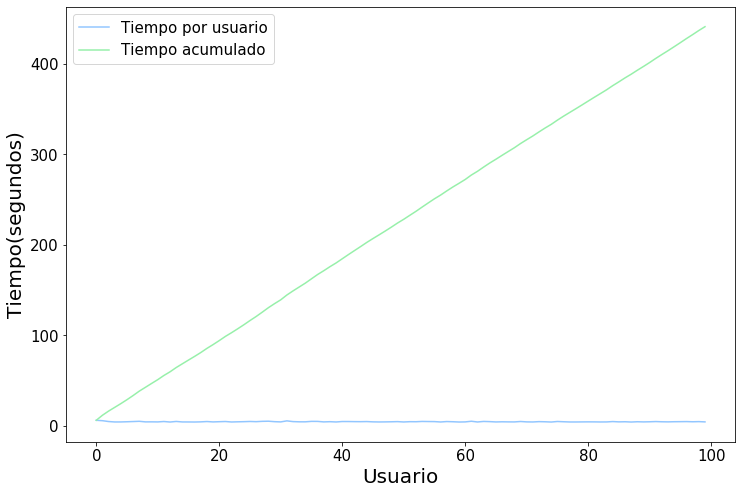

```python
simMatrix = getUser_UserSimilarity(TrainUISparseData, 100)
```

### Matrices de similaridad entre películas

```python
start = datetime.now()

if not os.path.isfile("../Data/m_m_similarity.npz"):
    print("La matriz de similaridad entre películas no exite en disco. Creando matriz...")

    m_m_similarity = cosine_similarity(TrainUISparseData.T, dense_output = False)
    print("Hecho")
    print("Dimensión de la matriz = {}".format(m_m_similarity.shape))
    print("Guardando matriz en disco")
    sparse.save_npz("../Data/m_m_similarity.npz", m_m_similarity)
else:
    print("El archivo exite en disco. Cargando...")
    m_m_similarity = sparse.load_npz("../Data/m_m_similarity.npz")
    print("Dimensión de la matriz = {}".format(m_m_similarity.shape))

print(datetime.now() - start)
```

```
El archivo exite en disco. Cargando...
Dimensión de la matriz = (17771, 17771)
0:00:26.568976
```

### Validación del funcionamiento

Elegimos una película al azar y calculamos las películas más parecidas.

```python
movie_ids = np.unique(m_m_similarity.nonzero())
```

```python
similar_movies_dict = dict()
for movie in movie_ids:
    smlr = np.argsort(-m_m_similarity[movie].toarray().ravel())[1:100]
    similar_movies_dict[movie] = smlr
```

```python
movie_titles_df = pd.read_csv(movie_file,sep = ",", header = None, names=['MovieID', 'Year_of_Release', 'Movie_Title'], index_col = "MovieID", encoding = "iso8859_2")
```

Introducimos el ID de la película de la película 'El diario de Bridget Jones' (Bridget Jones's Diary) y comprobamos el número de votos recibidos por este título, así cómo el número de películas similares encontradas.

```python
movieID_GR = 299

print("Nombre de la película (en inglés) -------> "+str(movie_titles_df.loc[movieID_GR][1]))

print("La película {} ha sido evaluada {} veces".format(movie_titles_df.loc[movieID_GR][1], TrainUISparseData[:,movieID_GR].getnnz()))

print("En el catálogo hay {} películas similares a {}".format(m_m_similarity[movieID_GR].count_nonzero(),movie_titles_df.loc[movieID_GR][1]))
```

```
Nombre de la película (en inglés) -------> Bridget Jones's Diary
La película Bridget Jones's Diary ha sido evaluada 67660 veces
En el catálogo hay 17397 películas similares a Bridget Jones's Diary
```

```python
all_similar = sorted(m_m_similarity[movieID_GR].toarray().ravel(), reverse = True)[1:]

similar_100 = all_similar[:101]
```

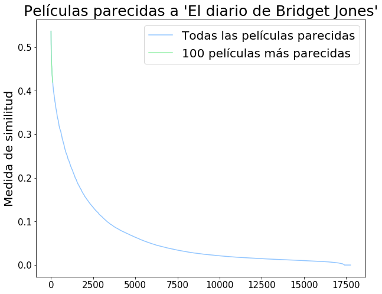

```python
plt.figure(figsize = (10, 8))
plt.plot(all_similar, label = "Todas las películas parecidas")
plt.plot(similar_100, label = "100 películas más parecidas")
plt.title("Películas parecidas a 'El diario de Bridget Jones'", fontsize = 25)
plt.ylabel("Medida de similitud", fontsize = 20)
plt.tick_params(labelsize = 15)
plt.legend(fontsize = 20)
plt.show()
```

#### ¿Cuáles son las 10 películas más parecidas a 'El diario de Bridget Jones'?

Como podemos observar en la tabla adjunta, el sistema de recomendación nos ofrece películas de género romántico y/o comedia,que coincide con las características de la película seleccionada, por lo que concluimos que la matriz funciona correctamente.

```python
movie_titles_df.loc[similar_movies_dict[movieID_GR][:10]]
```

| MovieID | Year_of_Release | Movie_Title |
| --- | --- | --- |
| 6206 | 2002.0 | My Big Fat Greek Wedding |
| 15058 | 1999.0 | Notting Hill |
| 3320 | 2002.0 | About a Boy |
| 16452 | 2000.0 | Chocolat |
| 17764 | 1998.0 | Shakespeare in Love |
| 2660 | 1989.0 | When Harry Met Sally |
| 17308 | 2001.0 | Legally Blonde |
| 13763 | 1996.0 | Jerry Maguire |
| 4472 | 2003.0 | Love Actually |
| 9728 | 1997.0 | As Good as It Gets |

## Modelos

Esta función comprueba si existe el archivo de la matriz de dispersión (en nuestro caso, la versión reducida, dado el límite de capacidad de cómputo). En caso contrario, lo crea. Aplicaremos esta función sobre los set de entrenamiento y validación.

```python
def get_sample_sparse_matrix(sparseMatrix, n_users, n_movies):
    startTime = datetime.now()
    users, movies, ratings = sparse.find(sparseMatrix)
    uniq_users = np.unique(users)
    uniq_movies = np.unique(movies)
    np.random.seed(15)
    userS = np.random.choice(uniq_users, n_users, replace = False)
    movieS = np.random.choice(uniq_movies, n_movies, replace = False)
    mask = np.logical_and(np.isin(users, userS), np.isin(movies, movieS))
    sparse_sample = sparse.csr_matrix((ratings[mask], (users[mask], movies[mask])),
                                                     shape = (max(userS)+1, max(movieS)+1))
    print("Creación de la matriz de dispersión terminada. Guardada para uso posterior.")
    sparse.save_npz(path, sparse_sample)
    print("Hecho")
    print("Dimensiones de la matriz de dispersión = "+str(sparse_sample.shape))

    print(datetime.now() - start)
    return sparse_sample
```

### Matriz de dispersión para set de entrenamiento

Tomamos una muestra de la matriz de dispersión, consistente en tomar 4000 usuarios y 400 películas.

```python
path = "TrainUISparseData_Sample.npz"
if not os.path.isfile(path):
    print("La matriz de dispersión no se encuentra en disco. Vamos a crearla")
    train_sample_sparse = get_sample_sparse_matrix(TrainUISparseData, 4000, 400)
else:
    print("El archivo está en disco. Cargando...")
    train_sample_sparse = sparse.load_npz(path)
    print("Carga completada.")
    print("Dimensiones de la matriz de dispersión = "+str(train_sample_sparse.shape))
```

```
El archivo está en disco. Cargando...
Carga completada.
Dimensiones de la matriz de dispersión = (2649232, 17724)
```

### Matriz de dispersión para set de validación

Tomamos una muestra de la matriz de dispersión de validación, con tan solo 2000 usuarios y 200 películas

```python
path = "TestUISparseData_Sample.npz"
if not os.path.isfile(path):
    print("La matriz de dispersión no se encuentra en disco. Vamos a crearla")
    test_sample_sparse = get_sample_sparse_matrix(TestUISparseData, 2000, 200)
else:
    print("El archivo está en disco. Cargando...")
    test_sample_sparse = sparse.load_npz(path)
    print("Carga completada.")
    print("Dimensiones de la matriz de dispersión = "+str(test_sample_sparse.shape))
```

```
El archivo está en disco. Cargando...
Carga completada.
Dimensiones de la matriz de dispersión = (2645677, 17551)
```

### Cálculo de los Promedios

Calculamos las medias de las puntuaciones global, por película y por usuario con el objetivo de incluirlas en el dataframe que utilizaremos para los modelos.

#### Media global para todas las películas.

```python
print("La media global para todas las películas en el set de entrenamiento es {}".format(np.round((train_sample_sparse.sum()/train_sample_sparse.count_nonzero()), 2)))
```

```
La media global para todas las películas en el set de entrenamiento es 3.63
```

#### Media de puntuaciones por película

```python
globalAvgMovies = getAverageRatings(train_sample_sparse, False)
print("La puntuación media de 'At home among strangers' {}".format(globalAvgMovies[72]))
```

```
La puntuación media de 'At home among strangers' 4.5
```

#### Media de puntuaciones por usuario

```python
globalAvgUsers = getAverageRatings(train_sample_sparse, True)
print("La media de puntos otorgada por el usuario 1374 es {}".format(globalAvgUsers[1374]))
```

```
La media de puntos otorgada por el usuario 1374 es 4.142857142857143
```

### Adaptación de la data para el problema de regresión

Construimos, a partir del trabajo realizado previamente, dos dataset (entrenamiento y validación,respectivamente), con los siguientes campos:

- **User_ID**
- **Movie_ID**
- **Global_Average**
- **Ratings given to this Movie by top 5 similar users with this User:** (SUR1, SUR2, SUR3, SUR4, SUR5)
- **Ratings given by this User to top 5 similar movies with this Movie:** (SMR1, SMR2, SMR3, SMR4, SMR5)
- **User_Average**
- **Movie_Average:**
- **Rating**

### Entrenamiento

```python
sample_train_users, sample_train_movies, sample_train_ratings = sparse.find(train_sample_sparse)
```

```python
if os.path.isfile("Train_Regression.csv"):
    print("El archivo ya existe.")
else:
    startTime = datetime.now()
    print("Preparando archivo csv Train para {} filas".format(len(sample_train_ratings)))
    with open("Train_Regression.csv", mode = "w") as data:
        count = 0
        for user, movie, rating in zip(sample_train_users, sample_train_movies, sample_train_ratings):
            row = list()
            row.append(user)
            row.append(movie)
            row.append(train_sample_sparse.sum()/train_sample_sparse.count_nonzero())

#----------------------------------Ratings given to "movie" by top 5 similar users with "user"--------------------#
            similar_users = cosine_similarity(train_sample_sparse[user], train_sample_sparse).ravel()
            similar_users_indices = np.argsort(-similar_users)[1:]
            similar_users_ratings = train_sample_sparse[similar_users_indices, movie].toarray().ravel()
            top_similar_user_ratings = list(similar_users_ratings[similar_users_ratings != 0][:5])
            top_similar_user_ratings.extend([globalAvgMovies[movie]]*(5-len(top_similar_user_ratings)))
            row.extend(top_similar_user_ratings)

 #----------------------------------Ratings given by "user" to top 5 similar movies with "movie"------------------#
            similar_movies = cosine_similarity(train_sample_sparse[:,movie].T, train_sample_sparse.T).ravel()
            similar_movies_indices = np.argsort(-similar_movies)[1:]
            similar_movies_ratings = train_sample_sparse[user, similar_movies_indices].toarray().ravel()
            top_similar_movie_ratings = list(similar_movies_ratings[similar_movies_ratings != 0][:5])
            top_similar_movie_ratings.extend([globalAvgUsers[user]]*(5-len(top_similar_movie_ratings)))
            row.extend(top_similar_movie_ratings)

 #----------------------------------Appending "user" average, "movie" average & rating of "user""movie"-----------#
            row.append(globalAvgUsers[user])
            row.append(globalAvgMovies[movie])
            row.append(rating)

#-----------------------------------Converting rows and appending them as comma separated values to csv file------#
            data.write(",".join(map(str, row)))
            data.write("\n")

            count += 1
            if count % 2000 == 0:
                print("Hecho para {}. Tiempo: {}".format(count, (datetime.now() - startTime)))

    print("Tiempo total para {} filas = {}".format(len(sample_train_ratings), (datetime.now() - startTime)))
```

```
El archivo ya existe.
```

```python
Train_Reg = pd.read_csv("Train_Regression.csv", names = ["User_ID", "Movie_ID", "Global_Average", "SUR1", "SUR2", "SUR3", "SUR4", "SUR5", "SMR1", "SMR2", "SMR3", "SMR4", "SMR5", "User_Average", "Movie_Average", "Rating"])
Train_Reg.head()
```

|  | User_ID | Movie_ID | Global_Average | SUR1 | SUR2 | SUR3 | SUR4 | SUR5 | SMR1 | SMR2 | SMR3 | SMR4 | SMR5 | User_Average | Movie_Average | Rating |
| --- | --- | --- | --- | --- | --- | --- | --- | --- | --- | --- | --- | --- | --- | --- | --- | --- |
| 0 | 53406 | 33 | 3.631623 | 4.0 | 3.0 | 4.0 | 3.0 | 3.0 | 5.0 | 2.0 | 1.0 | 3.0 | 5.0 | 3.423077 | 4.0 | 4 |
| 1 | 99865 | 33 | 3.631623 | 3.0 | 4.0 | 5.0 | 5.0 | 4.0 | 5.0 | 4.0 | 3.0 | 4.0 | 5.0 | 3.800000 | 4.0 | 5 |
| 2 | 112974 | 33 | 3.631623 | 4.0 | 3.0 | 5.0 | 5.0 | 5.0 | 3.0 | 5.0 | 2.0 | 5.0 | 3.0 | 4.125000 | 4.0 | 5 |
| 3 | 125275 | 33 | 3.631623 | 4.0 | 3.0 | 4.0 | 2.0 | 5.0 | 4.0 | 3.0 | 2.0 | 5.0 | 4.0 | 3.500000 | 4.0 | 4 |
| 4 | 149511 | 33 | 3.631623 | 4.0 | 5.0 | 4.0 | 5.0 | 5.0 | 5.0 | 5.0 | 4.0 | 4.0 | 4.0 | 4.055556 | 4.0 | 4 |

```python
print("Número de valores ausentes = "+str(Train_Reg.isnull().sum().sum()))
```

```
Número de valores ausentes = 0
```

```python
print("Dimensiones del dataframe de entrenamiento = {}".format(Train_Reg.shape))
```

```
Dimensiones del dataframe de entrenamiento = (21649, 16)
```

### Validación

```python
sample_test_users, sample_test_movies, sample_test_ratings = sparse.find(test_sample_sparse)
```

```python
if os.path.isfile("Test_Regression.csv"):
    print("File is already present in your disk. You do not have to prepare it again.")
else:
    startTime = datetime.now()
    print("Preparing Test csv file for {} rows".format(len(sample_test_ratings)))
    with open("Test_Regression.csv", mode = "w") as data:
        count = 0
        for user, movie, rating in zip(sample_test_users, sample_test_movies, sample_test_ratings):
            row = list()
            row.append(user)
            row.append(movie)
            row.append(train_sample_sparse.sum()/train_sample_sparse.count_nonzero())

#-----------------------------Ratings given to "movie" by top 5 similar users with "user"-------------------------#
            try:
                similar_users = cosine_similarity(train_sample_sparse[user], train_sample_sparse).ravel()
                similar_users_indices = np.argsort(-similar_users)[1:]
                similar_users_ratings = train_sample_sparse[similar_users_indices, movie].toarray().ravel()
                top_similar_user_ratings = list(similar_users_ratings[similar_users_ratings != 0][:5])
                top_similar_user_ratings.extend([globalAvgMovies[movie]]*(5-len(top_similar_user_ratings)))
                row.extend(top_similar_user_ratings)
            except(IndexError, KeyError):
                global_average_train_rating = [train_sample_sparse.sum()/train_sample_sparse.count_nonzero()]*5
                row.extend(global_average_train_rating)
            except:
                raise

 #-----------------------------Ratings given by "user" to top 5 similar movies with "movie"-----------------------#
            try:
                similar_movies = cosine_similarity(train_sample_sparse[:,movie].T, train_sample_sparse.T).ravel()
                similar_movies_indices = np.argsort(-similar_movies)[1:]
                similar_movies_ratings = train_sample_sparse[user, similar_movies_indices].toarray().ravel()
                top_similar_movie_ratings = list(similar_movies_ratings[similar_movies_ratings != 0][:5])
                top_similar_movie_ratings.extend([globalAvgUsers[user]]*(5-len(top_similar_movie_ratings)))
                row.extend(top_similar_movie_ratings)
            #########Cold Start Problem, for a new user or a new movie#########
            except(IndexError, KeyError):
                global_average_train_rating = [train_sample_sparse.sum()/train_sample_sparse.count_nonzero()]*5
                row.extend(global_average_train_rating)
            except:
                raise

 #-----------------------------Appending "user" average, "movie" average & rating of "user""movie"----------------#
            try:
                row.append(globalAvgUsers[user])
            except (KeyError):
                global_average_train_rating = train_sample_sparse.sum()/train_sample_sparse.count_nonzero()
                row.append(global_average_train_rating)
            except:
                raise

            try:
                row.append(globalAvgMovies[movie])
            except(KeyError):
                global_average_train_rating = train_sample_sparse.sum()/train_sample_sparse.count_nonzero()
                row.append(global_average_train_rating)
            except:
                raise

            row.append(rating)

#------------------------------Converting rows and appending them as comma separated values to csv file-----------#
            data.write(",".join(map(str, row)))
            data.write("\n")

            count += 1
            if count % 100 == 0:
                print("Hecho para {}. Tiempo: {}".format(count, (datetime.now() - startTime)))

    print("Tiempo total para {} filas = {}".format(len(sample_test_ratings), (datetime.now() - startTime)))
```

```
File is already present in your disk. You do not have to prepare it again.
```

```python
Test_Reg = pd.read_csv("Test_Regression.csv", names = ["User_ID", "Movie_ID", "Global_Average", "SUR1", "SUR2", "SUR3", "SUR4", "SUR5", "SMR1", "SMR2", "SMR3", "SMR4", "SMR5", "User_Average", "Movie_Average", "Rating"])
Test_Reg.head()
```

|  | User_ID | Movie_ID | Global_Average | SUR1 | SUR2 | SUR3 | SUR4 | SUR5 | SMR1 | SMR2 | SMR3 | SMR4 | SMR5 | User_Average | Movie_Average | Rating |
| --- | --- | --- | --- | --- | --- | --- | --- | --- | --- | --- | --- | --- | --- | --- | --- | --- |
| 0 | 808635 | 71 | 3.631623 | 3.631623 | 3.631623 | 3.631623 | 3.631623 | 3.631623 | 3.631623 | 3.631623 | 3.631623 | 3.631623 | 3.631623 | 3.631623 | 3.631623 | 5 |
| 1 | 941866 | 71 | 3.631623 | 3.631623 | 3.631623 | 3.631623 | 3.631623 | 3.631623 | 3.631623 | 3.631623 | 3.631623 | 3.631623 | 3.631623 | 3.631623 | 3.631623 | 4 |
| 2 | 2531303 | 251 | 3.631623 | 3.631623 | 3.631623 | 3.631623 | 3.631623 | 3.631623 | 3.631623 | 3.631623 | 3.631623 | 3.631623 | 3.631623 | 3.631623 | 3.631623 | 3 |
| 3 | 545915 | 309 | 3.631623 | 3.631623 | 3.631623 | 3.631623 | 3.631623 | 3.631623 | 3.631623 | 3.631623 | 3.631623 | 3.631623 | 3.631623 | 3.631623 | 3.631623 | 4 |
| 4 | 407528 | 420 | 3.631623 | 3.631623 | 3.631623 | 3.631623 | 3.631623 | 3.631623 | 3.631623 | 3.631623 | 3.631623 | 3.631623 | 3.631623 | 3.631623 | 3.631623 | 4 |

```python
print("Número de valores ausentes = "+str(Test_Reg.isnull().sum().sum()))
```

```
Número de valores ausentes = 0
```

```python
print("Dimensiones del dataframe de validación = {}".format(Test_Reg.shape))
```

```
Dimensiones del dataframe de validación = (1145, 16)
```

### Librería 'surprise'

Utilizaremos la librería surprise debido a que contiene algoritmos para la generación y evaluación de modelos, con la peculiaridad de contener un módulo de similitudes. Este módulo permite calcular la similitud entre pares de datos, mediante el cálculo del coseno.

Realizamos una transformación de los dataframe de entrenamiento y validación, para que concuerden en formato con los requerimientos del paquete 'surprise'

#### Training

```python
reader = Reader(rating_scale=(1, 5))

data = Dataset.load_from_df(Train_Reg[['User_ID', 'Movie_ID', 'Rating']], reader)

trainset = data.build_full_trainset()
```

#### Test

A diferencia del caso anterior, la data de test debe tener formato de tupla.

```python
testset = list(zip(Test_Reg["User_ID"].values, Test_Reg["Movie_ID"].values, Test_Reg["Rating"].values))
```

```python
testset[:5]
```

```
[(808635, 71, 5),
 (941866, 71, 4),
 (2531303, 251, 3),
 (545915, 309, 4),
 (407528, 420, 4)]
```

### Métricas

Nos basaremos en dos indicadores de error para la selección del modelo:

- RMSE
- MAPE

```python
error_table = pd.DataFrame(columns = ["Model", "Train RMSE", "Train MAPE", "Test RMSE", "Test MAPE"])
model_train_evaluation = dict()
model_test_evaluation = dict()
```

```python
def make_table(model_name, rmse_train, mape_train, rmse_test, mape_test):
    global error_table
    error_table = error_table.append(pd.DataFrame([[model_name, rmse_train, mape_train, rmse_test, mape_test]], columns = ["Model", "Train RMSE", "Train MAPE", "Test RMSE", "Test MAPE"]))
    error_table.reset_index(drop = True, inplace = True)
```

### Funciones comunes

```python
def error_metrics(y_true, y_pred):
    rmse = np.sqrt(mean_squared_error(y_true, y_pred))
    mape = np.mean(abs((y_true - y_pred)/y_true))*100
    return rmse, mape
```

```python
def train_test_xgboost(x_train, x_test, y_train, y_test, model_name):
    startTime = datetime.now()
    train_result = dict()
    test_result = dict()

    clf = xgb.XGBRegressor(n_estimators = 100, silent = False, n_jobs  = 10)
    clf.fit(x_train, y_train)

    print("-"*50)
    print("TRAIN DATA")
    y_pred_train = clf.predict(x_train)
    rmse_train, mape_train = error_metrics(y_train, y_pred_train)
    print("RMSE = {}".format(rmse_train))
    print("MAPE = {}".format(mape_train))
    print("-"*50)
    train_result = {"RMSE": rmse_train, "MAPE": mape_train, "Prediction": y_pred_train}

    print("TEST DATA")
    y_pred_test = clf.predict(x_test)
    rmse_test, mape_test = error_metrics(y_test, y_pred_test)
    print("RMSE = {}".format(rmse_test))
    print("MAPE = {}".format(mape_test))
    print("-"*50)
    test_result = {"RMSE": rmse_test, "MAPE": mape_test, "Prediction": y_pred_test}

    print("Time Taken = "+str(datetime.now() - startTime))

    plot_importance(xgb, clf)

    make_table(model_name, rmse_train, mape_train, rmse_test, mape_test)

    return train_result, test_result
```

```python
def plot_importance(model, clf):
    fig = plt.figure(figsize = (8, 6))
    ax = fig.add_axes([0,0,1,1])
    model.plot_importance(clf, ax = ax, height = 0.3)
    plt.xlabel("F Score", fontsize = 20)
    plt.ylabel("Features", fontsize = 20)
    plt.title("Feature Importance", fontsize = 20)
    plt.tick_params(labelsize = 15)

    plt.show()
```

```python
def get_ratings(predictions):
    actual = np.array([pred.r_ui for pred in predictions])
    predicted = np.array([pred.est for pred in predictions])
    return actual, predicted
```

```python
def get_error(predictions):
    actual, predicted = get_ratings(predictions)
    rmse = np.sqrt(mean_squared_error(actual, predicted))
    mape = np.mean(abs((actual - predicted)/actual))*100
    return rmse, mape
```

```python
my_seed = 15
random.seed(my_seed)
np.random.seed(my_seed)

def run_surprise(algo, trainset, testset, model_name):
    startTime = datetime.now()

    train = dict()
    test = dict()

    algo.fit(trainset)

#-----------------Evaluating Train Data------------------#
    print("-"*50)
    print("TRAIN DATA")
    train_pred = algo.test(trainset.build_testset())

    train_actual, train_predicted = get_ratings(train_pred)
    train_rmse, train_mape = get_error(train_pred)
    print("RMSE = {}".format(train_rmse))
    print("MAPE = {}".format(train_mape))
    print("-"*50)
    train = {"RMSE": train_rmse, "MAPE": train_mape, "Prediction": train_predicted}

#-----------------Evaluating Test Data------------------#
    print("TEST DATA")
    test_pred = algo.test(testset)

    test_actual, test_predicted = get_ratings(test_pred)
    test_rmse, test_mape = get_error(test_pred)
    print("RMSE = {}".format(test_rmse))
    print("MAPE = {}".format(test_mape))
    print("-"*50)
    test = {"RMSE": test_rmse, "MAPE": test_mape, "Prediction": test_predicted}

    print("Time Taken = "+str(datetime.now() - startTime))

    make_table(model_name, train_rmse, train_mape, test_rmse, test_mape)

    return train, test
```

### XGBoost

```
[20:19:18] WARNING: src/objective/regression_obj.cu:152: reg:linear is now deprecated in favor of reg:squarederror.
--------------------------------------------------
TRAIN DATA
RMSE = 0.7912793851932474
MAPE = 22.77544140815735
--------------------------------------------------
TEST DATA
RMSE = 1.0645762783910835
MAPE = 34.35508294744115
--------------------------------------------------
Time Taken = 0:00:00.539511
```

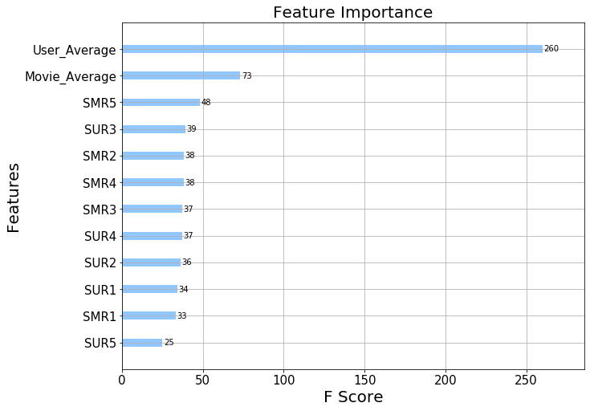

```python
x_train = Train_Reg.drop(["User_ID", "Movie_ID", "Rating"], axis = 1)

x_test = Test_Reg.drop(["User_ID", "Movie_ID", "Rating"], axis = 1)

y_train = Train_Reg["Rating"]

y_test = Test_Reg["Rating"]

train_result, test_result = train_test_xgboost(x_train, x_test, y_train, y_test, "XGBoost_13")

model_train_evaluation["XGBoost_13"] = train_result
model_test_evaluation["XGBoost_13"] = test_result
```

Como podemos observar, las variables más importantes en nuestro primer modelo XGBoost son las puntuaciones medias del usuario y la película.

### Modelo BaseLine

Definimos un modelo lineal en el que las variables predictoras son las siguientes:

#### Predicción de la calificación

> $\large\hat{r}_{ui} = \mu + b_u + b_i$
- $\mu$: Average Global Ratings in training data
- $b_u$: User-Bias
- $b_i$: Item-Bias

#### Función de optimización

> $\large \sum_{r_ui \in R_{Train}} \left(r_{ui} - (\mu + b_u + b_i)\right)^2 + \lambda \left(b_u^2 + b_i^2 \right). \left[minimize\; b_u, b_i \right]$

```python
bsl_options = {"method":"sgd", "learning_rate":0.01, "n_epochs":25}

algo = BaselineOnly(bsl_options=bsl_options)

train_result, test_result = run_surprise(algo, trainset, testset, "BaselineOnly")

model_train_evaluation["BaselineOnly"] = train_result
model_test_evaluation["BaselineOnly"] = test_result
```

```
Estimating biases using sgd...
--------------------------------------------------
TRAIN DATA
RMSE = 0.849510485353859
MAPE = 25.30957624296704
--------------------------------------------------
TEST DATA
RMSE = 1.062596409664951
MAPE = 34.56164687776601
--------------------------------------------------
Time Taken = 0:00:00.514623
```

### XGBoost + BaselineOnly

Modelo ensamblado de los modelos XGBoost y Linea Base. Para ello, agregamos las calificaciones pronosticadas del modelo BaselineOnly a nuestros datos de entrenamiento y prueba

```python
Train_Reg["BaselineOnly"] = model_train_evaluation["BaselineOnly"]["Prediction"]
```

```python
Train_Reg.head()
```

|  | User_ID | Movie_ID | Global_Average | SUR1 | SUR2 | SUR3 | SUR4 | SUR5 | SMR1 | SMR2 | SMR3 | SMR4 | SMR5 | User_Average | Movie_Average | Rating | BaselineOnly |
| --- | --- | --- | --- | --- | --- | --- | --- | --- | --- | --- | --- | --- | --- | --- | --- | --- | --- |
| 0 | 53406 | 33 | 3.631623 | 4.0 | 3.0 | 4.0 | 3.0 | 3.0 | 5.0 | 2.0 | 1.0 | 3.0 | 5.0 | 3.423077 | 4.0 | 4 | 3.757462 |
| 1 | 99865 | 33 | 3.631623 | 3.0 | 4.0 | 5.0 | 5.0 | 4.0 | 5.0 | 4.0 | 3.0 | 4.0 | 5.0 | 3.800000 | 4.0 | 5 | 2.899492 |
| 2 | 112974 | 33 | 3.631623 | 4.0 | 3.0 | 5.0 | 5.0 | 5.0 | 3.0 | 5.0 | 2.0 | 5.0 | 3.0 | 4.125000 | 4.0 | 5 | 3.611281 |
| 3 | 125275 | 33 | 3.631623 | 4.0 | 3.0 | 4.0 | 2.0 | 5.0 | 4.0 | 3.0 | 2.0 | 5.0 | 4.0 | 3.500000 | 4.0 | 4 | 3.296047 |
| 4 | 149511 | 33 | 3.631623 | 4.0 | 5.0 | 4.0 | 5.0 | 5.0 | 5.0 | 5.0 | 4.0 | 4.0 | 4.0 | 4.055556 | 4.0 | 4 | 2.742157 |

```python
print("Número de valores ausentes = "+str(Train_Reg.isnull().sum().sum()))
```

```
Número de valores ausentes = 0
```

```python
Test_Reg["BaselineOnly"] = model_test_evaluation["BaselineOnly"]["Prediction"]
Test_Reg.head()
```

|  | User_ID | Movie_ID | Global_Average | SUR1 | SUR2 | SUR3 | SUR4 | SUR5 | SMR1 | SMR2 | SMR3 | SMR4 | SMR5 | User_Average | Movie_Average | Rating | BaselineOnly |
| --- | --- | --- | --- | --- | --- | --- | --- | --- | --- | --- | --- | --- | --- | --- | --- | --- | --- |
| 0 | 808635 | 71 | 3.631623 | 3.631623 | 3.631623 | 3.631623 | 3.631623 | 3.631623 | 3.631623 | 3.631623 | 3.631623 | 3.631623 | 3.631623 | 3.631623 | 3.631623 | 5 | 3.631623 |
| 1 | 941866 | 71 | 3.631623 | 3.631623 | 3.631623 | 3.631623 | 3.631623 | 3.631623 | 3.631623 | 3.631623 | 3.631623 | 3.631623 | 3.631623 | 3.631623 | 3.631623 | 4 | 3.631623 |
| 2 | 2531303 | 251 | 3.631623 | 3.631623 | 3.631623 | 3.631623 | 3.631623 | 3.631623 | 3.631623 | 3.631623 | 3.631623 | 3.631623 | 3.631623 | 3.631623 | 3.631623 | 3 | 3.631623 |
| 3 | 545915 | 309 | 3.631623 | 3.631623 | 3.631623 | 3.631623 | 3.631623 | 3.631623 | 3.631623 | 3.631623 | 3.631623 | 3.631623 | 3.631623 | 3.631623 | 3.631623 | 4 | 3.631623 |
| 4 | 407528 | 420 | 3.631623 | 3.631623 | 3.631623 | 3.631623 | 3.631623 | 3.631623 | 3.631623 | 3.631623 | 3.631623 | 3.631623 | 3.631623 | 3.631623 | 3.631623 | 4 | 3.631623 |

```python
print("Número de valores ausentes = "+str(Test_Reg.isnull().sum().sum()))
```

```
Número de valores ausentes = 0
```

```
[20:19:46] WARNING: src/objective/regression_obj.cu:152: reg:linear is now deprecated in favor of reg:squarederror.
--------------------------------------------------
TRAIN DATA
RMSE = 0.791261194502895
MAPE = 22.776611149311066
--------------------------------------------------
TEST DATA
RMSE = 1.0643121075891007
MAPE = 34.39720424398093
--------------------------------------------------
Time Taken = 0:00:00.556511
```

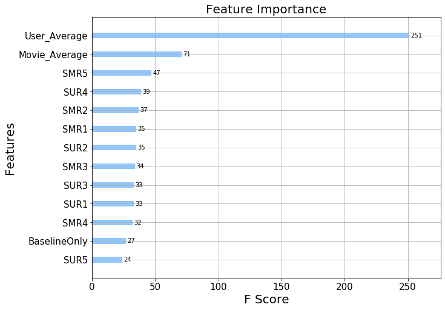

```python
x_train = Train_Reg.drop(["User_ID", "Movie_ID", "Rating"], axis = 1)

x_test = Test_Reg.drop(["User_ID", "Movie_ID", "Rating"], axis = 1)

y_train = Train_Reg["Rating"]

y_test = Test_Reg["Rating"]

train_result, test_result = train_test_xgboost(x_train, x_test, y_train, y_test, "XGB_BSL")

model_train_evaluation["XGB_BSL"] = train_result
model_test_evaluation["XGB_BSL"] = test_result
```

Como podemos observar, las variables más importantes coinciden con las estimadas en el modelo XGBoost.

### KNN-Baseline

#### KNN-Baseline para similitud entre usuarios.

El modelo KNN-Baseline se basa en el algoritmo de K-vecinos cercanos. En este caso, tomaremos nos N vecinos cercanos para los cuales la medida de similitud es positiva. Este modelo lo usaremos para estimar la similitud entre usuarios.

##### Cross- Validation

```python
param_grid  = {'sim_options':{'name': ["pearson_baseline"], "user_based": [True], "min_support": [2], "shrinkage": [60, 80, 80, 140]}, 'k': [5, 20, 40, 80]}

gs = GridSearchCV(KNNBaseline, param_grid, measures=['rmse', 'mae'], cv=3)

gs.fit(data)

# best RMSE score
print(gs.best_score['rmse'])

# combination of parameters that gave the best RMSE score
print(gs.best_params['rmse'])
```

[output not shown]

[output cut: 91 more lines]

```
Done computing similarity matrix.
Estimating biases using als...
Computing the pearson_baseline similarity matrix...
Done computing similarity matrix.
Estimating biases using als...
Computing the pearson_baseline similarity matrix...
Done computing similarity matrix.
Estimating biases using als...
Computing the pearson_baseline similarity matrix...
Done computing similarity matrix.
Estimating biases using als...
Computing the pearson_baseline similarity matrix...
Done computing similarity matrix.
0.9716245706888303
{'sim_options': {'name': 'pearson_baseline', 'user_based': True, 'min_support': 2, 'shrinkage': 60}, 'k': 80}
```

##### Mejores parámetros

Tras ejecutar Cross-Validation, aplicamos el modelo con los mejores parámetros:

```python
sim_options = {'name':'pearson_baseline', 'user_based':True, 'min_support':2, 'shrinkage':gs.best_params['rmse']['sim_options']['shrinkage']}

bsl_options = {'method': 'sgd'}

algo = KNNBaseline(k = gs.best_params['rmse']['k'], sim_options = sim_options, bsl_options=bsl_options)

train_result, test_result = run_surprise(algo, trainset, testset, "KNNBaseline_User")

model_train_evaluation["KNNBaseline_User"] = train_result
model_test_evaluation["KNNBaseline_User"] = test_result
```

```
Estimating biases using sgd...
Computing the pearson_baseline similarity matrix...
Done computing similarity matrix.
--------------------------------------------------
TRAIN DATA
RMSE = 0.29815184465824235
MAPE = 7.715926382392036
--------------------------------------------------
TEST DATA
RMSE = 1.0622877229996306
MAPE = 34.54711168456588
--------------------------------------------------
Time Taken = 0:00:13.431077
```

#### KNN-Baseline para similitud entre películas.

##### Cross- Validation

```python
param_grid  = {'sim_options':{'name': ["pearson_baseline"], "user_based": [False], "min_support": [2], "shrinkage": [60, 80, 80, 140]}, 'k': [5, 20, 40, 80]}

gs = GridSearchCV(KNNBaseline, param_grid, measures=['rmse', 'mae'], cv=3)

gs.fit(data)

# best RMSE score
print(gs.best_score['rmse'])

# combination of parameters that gave the best RMSE score
print(gs.best_params['rmse'])
```

[output not shown]

[output cut: 91 more lines]

```
Done computing similarity matrix.
Estimating biases using als...
Computing the pearson_baseline similarity matrix...
Done computing similarity matrix.
Estimating biases using als...
Computing the pearson_baseline similarity matrix...
Done computing similarity matrix.
Estimating biases using als...
Computing the pearson_baseline similarity matrix...
Done computing similarity matrix.
Estimating biases using als...
Computing the pearson_baseline similarity matrix...
Done computing similarity matrix.
1.051445933019681
{'sim_options': {'name': 'pearson_baseline', 'user_based': False, 'min_support': 2, 'shrinkage': 60}, 'k': 40}
```

##### Mejores parámetros

Análogamente al apartado anterior, tras ejecutar Cross-Validation, aplicamos el modelo con los mejores parámetros:

```python
sim_options = {'name':'pearson_baseline', 'user_based':False, 'min_support':2, 'shrinkage':gs.best_params['rmse']['sim_options']['shrinkage']}

bsl_options = {'method': 'sgd'}

algo = KNNBaseline(k = gs.best_params['rmse']['k'], sim_options = sim_options, bsl_options=bsl_options)

train_result, test_result = run_surprise(algo, trainset, testset, "KNNBaseline_Item")

model_train_evaluation["KNNBaseline_Item"] = train_result
model_test_evaluation["KNNBaseline_Item"] = test_result
```

```
Estimating biases using sgd...
Computing the pearson_baseline similarity matrix...
Done computing similarity matrix.
--------------------------------------------------
TRAIN DATA
RMSE = 0.1701377214044707
MAPE = 3.900637423707699
--------------------------------------------------
TEST DATA
RMSE = 1.0624812295324069
MAPE = 34.55775826820036
--------------------------------------------------
Time Taken = 0:00:01.081148
```

### XGBoost + BaselineOnly + KNN Baseline

Continuamos construyendo un dataframe consolidado, añadiendo los resultados de los modelos anteriores a nuestro dataset de entrenamiento y validación:

- Calificación pronosticada por BaselineOnly
- Calificación del usuario estimada por KNN
- Calificación de la película estimada por KNN

Finalmente, ejecutamos XGBoost sobre estos datos.

```python
Train_Reg["KNNBaseline_User"] = model_train_evaluation["KNNBaseline_User"]["Prediction"]
Train_Reg["KNNBaseline_Item"] = model_train_evaluation["KNNBaseline_Item"]["Prediction"]

Test_Reg["KNNBaseline_User"] = model_test_evaluation["KNNBaseline_User"]["Prediction"]
Test_Reg["KNNBaseline_Item"] = model_test_evaluation["KNNBaseline_Item"]["Prediction"]
```

```python
Train_Reg.head()
```

|  | User_ID | Movie_ID | Global_Average | SUR1 | SUR2 | SUR3 | SUR4 | SUR5 | SMR1 | SMR2 | SMR3 | SMR4 | SMR5 | User_Average | Movie_Average | Rating | BaselineOnly | KNNBaseline_User | KNNBaseline_Item |
| --- | --- | --- | --- | --- | --- | --- | --- | --- | --- | --- | --- | --- | --- | --- | --- | --- | --- | --- | --- |
| 0 | 53406 | 33 | 3.631623 | 4.0 | 3.0 | 4.0 | 3.0 | 3.0 | 5.0 | 2.0 | 1.0 | 3.0 | 5.0 | 3.423077 | 4.0 | 4 | 3.757462 | 3.903386 | 3.853311 |
| 1 | 99865 | 33 | 3.631623 | 3.0 | 4.0 | 5.0 | 5.0 | 4.0 | 5.0 | 4.0 | 3.0 | 4.0 | 5.0 | 3.800000 | 4.0 | 5 | 2.899492 | 2.957565 | 2.991312 |
| 2 | 112974 | 33 | 3.631623 | 4.0 | 3.0 | 5.0 | 5.0 | 5.0 | 3.0 | 5.0 | 2.0 | 5.0 | 3.0 | 4.125000 | 4.0 | 5 | 3.611281 | 3.231705 | 3.138317 |
| 3 | 125275 | 33 | 3.631623 | 4.0 | 3.0 | 4.0 | 2.0 | 5.0 | 4.0 | 3.0 | 2.0 | 5.0 | 4.0 | 3.500000 | 4.0 | 4 | 3.296047 | 3.087344 | 2.779591 |
| 4 | 149511 | 33 | 3.631623 | 4.0 | 5.0 | 4.0 | 5.0 | 5.0 | 5.0 | 5.0 | 4.0 | 4.0 | 4.0 | 4.055556 | 4.0 | 4 | 2.742157 | 2.954705 | 2.993261 |

```python
print("Número de valores ausentes "+str(Train_Reg.isnull().sum().sum()))
```

```
Número de valores ausentes 0
```

```python
Test_Reg.head()
```

|  | User_ID | Movie_ID | Global_Average | SUR1 | SUR2 | SUR3 | SUR4 | SUR5 | SMR1 | SMR2 | SMR3 | SMR4 | SMR5 | User_Average | Movie_Average | Rating | BaselineOnly | KNNBaseline_User | KNNBaseline_Item |
| --- | --- | --- | --- | --- | --- | --- | --- | --- | --- | --- | --- | --- | --- | --- | --- | --- | --- | --- | --- |
| 0 | 808635 | 71 | 3.631623 | 3.631623 | 3.631623 | 3.631623 | 3.631623 | 3.631623 | 3.631623 | 3.631623 | 3.631623 | 3.631623 | 3.631623 | 3.631623 | 3.631623 | 5 | 3.631623 | 3.631623 | 3.631623 |
| 1 | 941866 | 71 | 3.631623 | 3.631623 | 3.631623 | 3.631623 | 3.631623 | 3.631623 | 3.631623 | 3.631623 | 3.631623 | 3.631623 | 3.631623 | 3.631623 | 3.631623 | 4 | 3.631623 | 3.631623 | 3.631623 |
| 2 | 2531303 | 251 | 3.631623 | 3.631623 | 3.631623 | 3.631623 | 3.631623 | 3.631623 | 3.631623 | 3.631623 | 3.631623 | 3.631623 | 3.631623 | 3.631623 | 3.631623 | 3 | 3.631623 | 3.631623 | 3.631623 |
| 3 | 545915 | 309 | 3.631623 | 3.631623 | 3.631623 | 3.631623 | 3.631623 | 3.631623 | 3.631623 | 3.631623 | 3.631623 | 3.631623 | 3.631623 | 3.631623 | 3.631623 | 4 | 3.631623 | 3.631623 | 3.631623 |
| 4 | 407528 | 420 | 3.631623 | 3.631623 | 3.631623 | 3.631623 | 3.631623 | 3.631623 | 3.631623 | 3.631623 | 3.631623 | 3.631623 | 3.631623 | 3.631623 | 3.631623 | 4 | 3.631623 | 3.631623 | 3.631623 |

```python
print("Number of nan values in Test Data "+str(Test_Reg.isnull().sum().sum()))
```

```
Number of nan values in Test Data 0
```

```
[20:23:15] WARNING: src/objective/regression_obj.cu:152: reg:linear is now deprecated in favor of reg:squarederror.
--------------------------------------------------
TRAIN DATA
RMSE = 0.7911422893481691
MAPE = 22.77335226535797
--------------------------------------------------
TEST DATA
RMSE = 1.0644337794468397
MAPE = 34.34499533762895
--------------------------------------------------
Time Taken = 0:00:00.640289
```

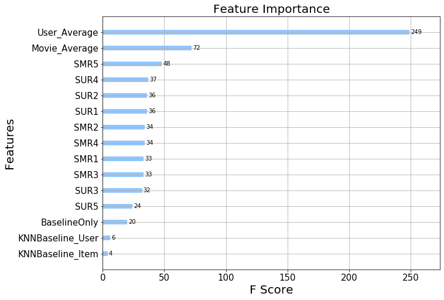

```python
x_train = Train_Reg.drop(["User_ID", "Movie_ID", "Rating"], axis = 1)

x_test = Test_Reg.drop(["User_ID", "Movie_ID", "Rating"], axis = 1)

y_train = Train_Reg["Rating"]

y_test = Test_Reg["Rating"]

train_result, test_result = train_test_xgboost(x_train, x_test, y_train, y_test, "XGB_BSL_KNN")

model_train_evaluation["XGB_BSL_KNN"] = train_result
model_test_evaluation["XGB_BSL_KNN"] = test_result
```

La adición de nuevas variables a nuestro dataset no cambia el orden de importancia de las variables, aunque se puede observar una ligera disminución del FScore según se añaden nuevas variables.

### Matrix Factorization SVD

Este algoritmo se popularizó a raíz del concurso de Netflix estudiado en este ejercicio.

Este modelo estima la calificación a través de factorización matricial.

#### La predicción $\hat{r}_{ui}$ se define como:

$\large \hat{r}_{ui} = \mu + b_u + b_i + q_i^Tp_u$

- $\pmb q_i$ - Representation of item(movie) in latent factor space
- $\pmb p_u$ - Representation of user in new latent factor space

Si se trata de un usuario nuevo o desconocido, entonces el bias $b_u$ y los factores $p_u$ se consideran 0. Lo mismo ocurre en el caso de la película(con $b_i$ y $q_i$.)

#### Función de optimización

$\large \sum_{r_{ui} \in R_{train}} \left(r_{ui} - \hat{r}_{ui} \right)^2 + \lambda\left(b_i^2 + b_u^2 + ||q_i||^2 + ||p_u||^2\right) \left[minimize\; b_u, b_i, q_i, p_u \right]$

#### Cross- Validation

```python
param_grid  = {'n_factors': [5,7,10,15,20,25,35,50,70,90]}

gs = GridSearchCV(SVD, param_grid, measures=['rmse', 'mae'], cv=3)

gs.fit(data)

print(gs.best_score['rmse'])

print(gs.best_params['rmse'])
```

```
0.9511068590869048
{'n_factors': 5}
```

#### Mejores parámetros

Utilizamos los mejores parámetros obtenidos a través de Cross-Validation:

```python
algo = SVD(n_factors = gs.best_params['rmse']['n_factors'], biased=True, verbose=True)

train_result, test_result = run_surprise(algo, trainset, testset, "SVD")

model_train_evaluation["SVD"] = train_result
model_test_evaluation["SVD"] = test_result
```

```
Processing epoch 0
Processing epoch 1
Processing epoch 2
Processing epoch 3
Processing epoch 4
Processing epoch 5
Processing epoch 6
Processing epoch 7
Processing epoch 8
Processing epoch 9
Processing epoch 10
Processing epoch 11
Processing epoch 12
Processing epoch 13
Processing epoch 14
Processing epoch 15
Processing epoch 16
Processing epoch 17
Processing epoch 18
Processing epoch 19
--------------------------------------------------
TRAIN DATA
RMSE = 0.8620123178579171
MAPE = 26.156451436415836
--------------------------------------------------
TEST DATA
RMSE = 1.0624867118808234
MAPE = 34.558276357775114
--------------------------------------------------
Time Taken = 0:00:00.630353
```

### Modelo SVD++

Este modelo se diferencia del modelo SVD por capturar, de forma adicional, las clasificaciones implícitas. Aquí, una calificación implícita describe el hecho de que un usuario u calificó un elemento j, independientemente del valor de la calificación.

$ y_i $ es un vector de elemento. Para cada elemento j, hay un vector de elemento $ y_j $ que es una retroalimentación implícita. La retroalimentación implícita refleja indirectamente la opinión al observar el comportamiento del usuario. La retroalimentación implícita generalmente denota la presencia o ausencia de un evento. Por ejemplo, hay una película 10 donde el usuario acaba de verificar los detalles de la película y pasar algún tiempo allí, contribuirá a la calificación implícita.

Ahora, desde aquí, Netflix no nos ha proporcionado los detalles de cuánto tiempo ha pasado un usuario en la película, por lo que aquí estamos considerando el hecho de que incluso si un usuario ha calificado alguna película, significa que ha pasado algún tiempo en esa película que contribuye a la calificación implícita.

#### La predicción $\hat{r}_{ui}$ se define como:

$\large \hat{r}_{ui} = \mu + b_u + b_i + q_i^T\left(p_u + |I_u|^{-\frac{1}{2}} \sum_{j \in I_u}y_j\right)$

- $ \pmb{I_u}$ --- lista de películas calificadas por el usuario u. $|I_u|$ es la longitud del conjunto.
- $\pmb{y_j}$ --- calificación implícita

Si se trata de un usuario nuevo o desconocido, entonces el bias $b_u$ y los factores $p_u$ se consideran 0. Lo mismo ocurre en el caso de la película(con $b_i$ y $q_i$.)

#### Función de optimización

$\large \sum_{r_{ui} \in R_{train}} \left(r_{ui} - \hat{r}_{ui} \right)^2 + \lambda\left(b_i^2 + b_u^2 + ||q_i||^2 + ||p_u||^2 + ||y_j||^2\right).\left[minimize\; b_u, b_i, q_i, p_u, y_j \right]$

#### Cross- Validation

```python
param_grid = {'n_factors': [10, 30, 50, 80, 100], 'lr_all': [0.002, 0.006, 0.018, 0.054, 0.10]}

gs = GridSearchCV(SVDpp, param_grid, measures=['rmse', 'mae'], cv=3)

gs.fit(data)

# best RMSE score
print(gs.best_score['rmse'])

# combination of parameters that gave the best RMSE score
print(gs.best_params['rmse'])
```

```
0.9561256161941972
{'n_factors': 10, 'lr_all': 0.006}
```

#### Mejores parámetros

Aplicamos los mejores parámetros, obtenidos por Cross-Validation:

```python
algo = SVDpp(n_factors = gs.best_params['rmse']['n_factors'], lr_all = gs.best_params['rmse']["lr_all"], verbose=True)

train_result, test_result = run_surprise(algo, trainset, testset, "SVDpp")

model_train_evaluation["SVDpp"] = train_result
model_test_evaluation["SVDpp"] = test_result
```

```
 processing epoch 0
 processing epoch 1
 processing epoch 2
 processing epoch 3
 processing epoch 4
 processing epoch 5
 processing epoch 6
 processing epoch 7
 processing epoch 8
 processing epoch 9
 processing epoch 10
 processing epoch 11
 processing epoch 12
 processing epoch 13
 processing epoch 14
 processing epoch 15
 processing epoch 16
 processing epoch 17
 processing epoch 18
 processing epoch 19
--------------------------------------------------
TRAIN DATA
RMSE = 0.7762232648743335
MAPE = 23.06514182063479
--------------------------------------------------
TEST DATA
RMSE = 1.0624829017941821
MAPE = 34.55876848030167
--------------------------------------------------
Time Taken = 0:00:05.846399
```

### XGBoost + BaselineOnly + KNN Baseline + SVD + SVD++

Agregamos al modelo ensamblado anterior los cálculos realizados a través de los modelos SVD y SVD++

```python
Train_Reg["SVD"] = model_train_evaluation["SVD"]["Prediction"]
Train_Reg["SVDpp"] = model_train_evaluation["SVDpp"]["Prediction"]

Test_Reg["SVD"] = model_test_evaluation["SVD"]["Prediction"]
Test_Reg["SVDpp"] = model_test_evaluation["SVDpp"]["Prediction"]
```

```python
Train_Reg.head()
```

|  | User_ID | Movie_ID | Global_Average | SUR1 | SUR2 | SUR3 | SUR4 | SUR5 | SMR1 | SMR2 | ... | SMR4 | SMR5 | User_Average | Movie_Average | Rating | BaselineOnly | KNNBaseline_User | KNNBaseline_Item | SVD | SVDpp |
| --- | --- | --- | --- | --- | --- | --- | --- | --- | --- | --- | --- | --- | --- | --- | --- | --- | --- | --- | --- | --- | --- |
| 0 | 53406 | 33 | 3.631623 | 4.0 | 3.0 | 4.0 | 3.0 | 3.0 | 5.0 | 2.0 | ... | 3.0 | 5.0 | 3.423077 | 4.0 | 4 | 3.757462 | 3.903386 | 3.853311 | 3.812247 | 3.829118 |
| 1 | 99865 | 33 | 3.631623 | 3.0 | 4.0 | 5.0 | 5.0 | 4.0 | 5.0 | 4.0 | ... | 4.0 | 5.0 | 3.800000 | 4.0 | 5 | 2.899492 | 2.957565 | 2.991312 | 2.998710 | 3.026833 |
| 2 | 112974 | 33 | 3.631623 | 4.0 | 3.0 | 5.0 | 5.0 | 5.0 | 3.0 | 5.0 | ... | 5.0 | 3.0 | 4.125000 | 4.0 | 5 | 3.611281 | 3.231705 | 3.138317 | 3.618495 | 3.553996 |
| 3 | 125275 | 33 | 3.631623 | 4.0 | 3.0 | 4.0 | 2.0 | 5.0 | 4.0 | 3.0 | ... | 5.0 | 4.0 | 3.500000 | 4.0 | 4 | 3.296047 | 3.087344 | 2.779591 | 3.289511 | 3.292630 |
| 4 | 149511 | 33 | 3.631623 | 4.0 | 5.0 | 4.0 | 5.0 | 5.0 | 5.0 | 5.0 | ... | 4.0 | 4.0 | 4.055556 | 4.0 | 4 | 2.742157 | 2.954705 | 2.993261 | 2.891880 | 2.936956 |

5 rows × 21 columns

```python
print("Número de valores ausentes "+str(Train_Reg.isnull().sum().sum()))
```

```
Número de valores ausentes 0
```

```python
Test_Reg.head()
```

|  | User_ID | Movie_ID | Global_Average | SUR1 | SUR2 | SUR3 | SUR4 | SUR5 | SMR1 | SMR2 | ... | SMR4 | SMR5 | User_Average | Movie_Average | Rating | BaselineOnly | KNNBaseline_User | KNNBaseline_Item | SVD | SVDpp |
| --- | --- | --- | --- | --- | --- | --- | --- | --- | --- | --- | --- | --- | --- | --- | --- | --- | --- | --- | --- | --- | --- |
| 0 | 808635 | 71 | 3.631623 | 3.631623 | 3.631623 | 3.631623 | 3.631623 | 3.631623 | 3.631623 | 3.631623 | ... | 3.631623 | 3.631623 | 3.631623 | 3.631623 | 5 | 3.631623 | 3.631623 | 3.631623 | 3.631623 | 3.631623 |
| 1 | 941866 | 71 | 3.631623 | 3.631623 | 3.631623 | 3.631623 | 3.631623 | 3.631623 | 3.631623 | 3.631623 | ... | 3.631623 | 3.631623 | 3.631623 | 3.631623 | 4 | 3.631623 | 3.631623 | 3.631623 | 3.631623 | 3.631623 |
| 2 | 2531303 | 251 | 3.631623 | 3.631623 | 3.631623 | 3.631623 | 3.631623 | 3.631623 | 3.631623 | 3.631623 | ... | 3.631623 | 3.631623 | 3.631623 | 3.631623 | 3 | 3.631623 | 3.631623 | 3.631623 | 3.631623 | 3.631623 |
| 3 | 545915 | 309 | 3.631623 | 3.631623 | 3.631623 | 3.631623 | 3.631623 | 3.631623 | 3.631623 | 3.631623 | ... | 3.631623 | 3.631623 | 3.631623 | 3.631623 | 4 | 3.631623 | 3.631623 | 3.631623 | 3.631623 | 3.631623 |
| 4 | 407528 | 420 | 3.631623 | 3.631623 | 3.631623 | 3.631623 | 3.631623 | 3.631623 | 3.631623 | 3.631623 | ... | 3.631623 | 3.631623 | 3.631623 | 3.631623 | 4 | 3.631623 | 3.631623 | 3.631623 | 3.631623 | 3.631623 |

5 rows × 21 columns

```python
print("Número de valores ausentes "+str(Test_Reg.isnull().sum().sum()))
```

```
Número de valores ausentes 0
```

```
[20:30:33] WARNING: src/objective/regression_obj.cu:152: reg:linear is now deprecated in favor of reg:squarederror.
```

```
--------------------------------------------------
TRAIN DATA
RMSE = 0.791164057343891
MAPE = 22.775249183177948
--------------------------------------------------
TEST DATA
RMSE = 1.0643216517209473
MAPE = 34.511250797144314
--------------------------------------------------
Time Taken = 0:00:00.621339
```

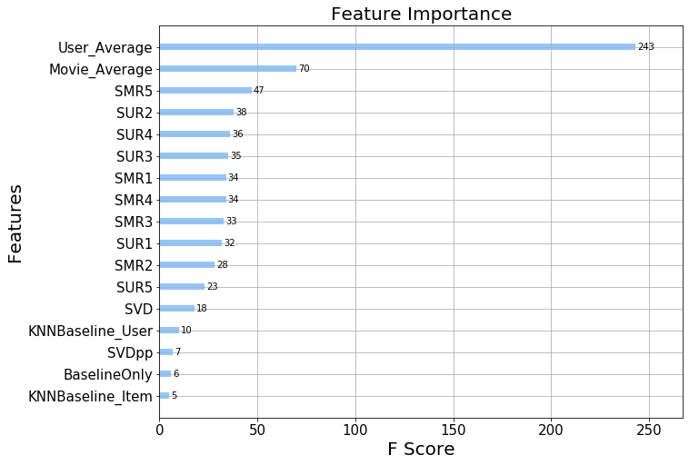

```python
x_train = Train_Reg.drop(["User_ID", "Movie_ID", "Rating"], axis = 1)

x_test = Test_Reg.drop(["User_ID", "Movie_ID", "Rating"], axis = 1)

y_train = Train_Reg["Rating"]

y_test = Test_Reg["Rating"]

train_result, test_result = train_test_xgboost(x_train, x_test, y_train, y_test, "XGB_BSL_KNN_MF")

model_train_evaluation["XGB_BSL_KNN_MF"] = train_result
model_test_evaluation["XGB_BSL_KNN_MF"] = test_result
```

### KNN Baseline + SVD + SVD++

En este apartado final, estimamos un modelo XGBoost a partir de los datos obtenido de los modelos KNN Baseline, SVD y SVD++. Como podemos observar, el modelo SVD parece ofrecer una métrica más significativa para un modelo de predicción.

```
[20:30:34] WARNING: src/objective/regression_obj.cu:152: reg:linear is now deprecated in favor of reg:squarederror.
--------------------------------------------------
TRAIN DATA
RMSE = 1.0561868045007243
MAPE = 33.98525416851044
--------------------------------------------------
TEST DATA
RMSE = 1.0626787325739366
MAPE = 34.516994872641405
--------------------------------------------------
Time Taken = 0:00:00.432842
```

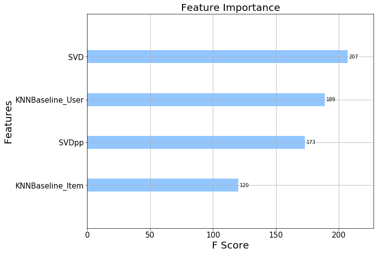

```python
x_train = Train_Reg[["KNNBaseline_User", "KNNBaseline_Item", "SVD", "SVDpp"]]

x_test = Test_Reg[["KNNBaseline_User", "KNNBaseline_Item", "SVD", "SVDpp"]]

y_train = Train_Reg["Rating"]

y_test = Test_Reg["Rating"]

train_result, test_result = train_test_xgboost(x_train, x_test, y_train, y_test, "XGB_KNN_MF")

model_train_evaluation["XGB_KNN_MF"] = train_result
model_test_evaluation["XGB_KNN_MF"] = test_result
```

## Conclusiones

A continuación realizamos una representación comparativa gráfica y numérica de estas medidas.

```python
error_table2 = error_table.drop(["Train MAPE", "Test MAPE"], axis = 1)
```

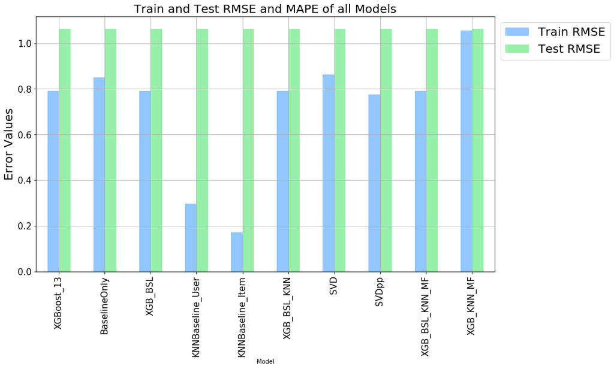

```python
error_table2.plot(x = "Model", kind = "bar", figsize = (14, 8), grid = True, fontsize = 15)
plt.title("Train and Test RMSE and MAPE of all Models", fontsize = 20)
plt.ylabel("Error Values", fontsize = 20)
plt.legend(bbox_to_anchor=(1, 1), fontsize = 20)
plt.show()
```

```python
error_table.drop(["Train MAPE", "Test MAPE"], axis = 1)
```

|  | Model | Train RMSE | Test RMSE |
| --- | --- | --- | --- |
| 0 | XGBoost_13 | 0.791279 | 1.064576 |
| 1 | BaselineOnly | 0.849510 | 1.062596 |
| 2 | XGB_BSL | 0.791261 | 1.064312 |
| 3 | KNNBaseline_User | 0.298152 | 1.062288 |
| 4 | KNNBaseline_Item | 0.170138 | 1.062481 |
| 5 | XGB_BSL_KNN | 0.791142 | 1.064434 |
| 6 | SVD | 0.862012 | 1.062487 |
| 7 | SVDpp | 0.776223 | 1.062483 |
| 8 | XGB_BSL_KNN_MF | 0.791164 | 1.064322 |
| 9 | XGB_KNN_MF | 1.056187 | 1.062679 |

# Bibliografía

- https://www.kaggle.com/netflix-inc/netflix-prize-data
- [1] https://es.wikipedia.org/wiki/Arranque_en_fr%C3%ADo
- https://es.wikipedia.org/wiki/Matriz_dispersa
- https://surprise.readthedocs.io/en/stable/matrix_factorization.html
- https://blog.statsbot.co/singular-value-decomposition-tutorial-52c695315254
- https://www.youtube.com/watch?v=ZspR5PZemcs